# MMRFVariant - Introduction

```r
library(MMRFVariant)
library(dplyr)
library(DT)
library(ggplot2)
library(stringr)
library(ggpubr)
library(survminer)
library(survival)
library(formattable)
```

## Introduction

MMRF-CoMMpass data can be retrieved directly from [MMRF-Commpass Researcher Gateway](https://research.themmrf.org/). They can be downloaded and imported as a dataframe into R environment.

### Fetching and importing MMRF-COMMPASS datasets

In this example we will fetch the MMRF-CoMMpass data from MMRF-COMMPASS Research Gateway (MMRF-RG). Once the dataset (.csv files) is imported into our own R environment, it is can be explored as a R-dataframe.

```r
patient <- read.csv("~/MMRF_CoMMpass_IA15_PER_PATIENT")
trt <- read.csv("~/MMRF_CoMMpass_IA15_STAND_ALONE_TRTRESP")
variant.ann <- read.csv("~/MMRF_CoMMpass_IA15a_All_Canonical_Variants")
```

### MMRFVariant functions

The table below shows an overview of the MMRFVariant functions and their outputs.

| **Function** | **Output** |
| --- | --- |
| MMRFVariant_PlotbyEffectImpact | N# of variants classified by Impact and Effect |
| MMRFVariant_PlotVariantsbyGene | Heatmap of the N# of variants |
| MMRFVariant_GetVariantsbyGene | list of SNPs occurring in the gene set |
| MMRFVariant_SurvivalKM | KM Survival curves |
| MMRFVariant_GetImpact | Impact table of SNPs |

### MMRFVariant Use-Case

For a more intuitive interpretation of the results, MMRFVariant provides a graphical or tabular representation of the outputs. The use-case diagram shown below provides an overview of the MMRFVariant functionalities and the different scenarios that can be performed.

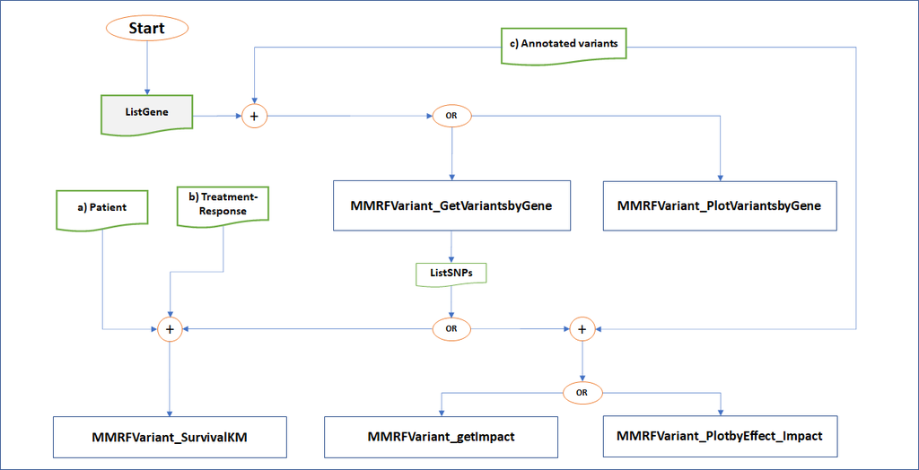

### Testing MMRFVariant functions

In order to test the MMRFVariant functions (without fetch MMRF-CoMMpass data from MMRF-RG), three fictitious datasets are provided in the “data” directory:

- <variant.ann.example>
- <patient.example>
- <trt.example>

They replicate the original datasets format icluding only some fileds with respect to MMRF-CoMMpass datasets (.csv files) downloaded from MMRF-COMMPASS Research Gateway.

**Annotated variant dataframe**

```r
datatable(variant.ann.example,options = list(scrollX = TRUE, keys = TRUE))
```

|  | public_id | ID | Effect | Impact |
| --- | --- | --- | --- | --- |
| 1 | MMRF_0000 | rs755588843 | intragenic_variant | MODERATE |
| 2 | MMRF_0001 | rs755588843 | intragenic_variant | MODERATE |
| 3 | MMRF_0002 | rs569344016 | intragenic_variant | MODIFIER |
| 4 | MMRF_0003 | rs569344016 | missense_variant | MODIFIER |
| 5 | MMRF_0004 | rs569344016 | missense_variant | LOW |
| 6 | MMRF_0005 | rs569344016 | intron_variant | LOW |
| 7 | MMRF_0006 | rs569344016 | 5_prime_UTR_variant | LOW |
| 8 | MMRF_0007 | rs2066497 | 5_prime_UTR_variant | HIGH |
| 9 | MMRF_0008 | rs2066497 | 5_prime_UTR_variant | HIGH |
| 10 | MMRF_0009 | . | 5_prime_UTR_variant | MODIFIER |

**Patient dataframe**

```r
datatable(patient.example,options = list(scrollX = TRUE, keys = TRUE))
```

|  | public_id | D_PT_PRIMARYREASON | D_PT_deathdy | D_PT_lstalive | DEMOG_GENDER | DEMOG_ETHNICITY | D_PT_issstage_char |
| --- | --- | --- | --- | --- | --- | --- | --- |
| 1 | MMRF_0000 | Death |  | 250 | 1 | Hispanic or Latino | Stage III |
| 2 | MMRF_0001 |  |  | 356 | 1 | Hispanic or Latino | Stage III |
| 3 | MMRF_0002 |  | 2226 |  | 1 | Hispanic or Latino | Stage III |
| 4 | MMRF_0003 | Death | 172 |  | 1 | Hispanic or Latino | Stage II |
| 5 | MMRF_0004 | Death |  | 1814 | 1 | Hispanic or Latino | Stage II |
| 6 | MMRF_0005 | Death |  | 223 | 2 | Not Hispanic or Latino | Stage I |
| 7 | MMRF_0006 | NA | 1328 |  | 2 | Not Hispanic or Latino | Stage I |
| 8 | MMRF_0007 | NA | 681 |  | 2 | Not Hispanic or Latino | Stage I |
| 9 | MMRF_0008 | Death | 786 |  | 2 | Not Hispanic or Latino | Stage I |
| 10 | MMRF_0009 | Death |  | 1450 | 2 | Not Hispanic or Latino | Stage I |

**Treatment dataframe**

```r
datatable(trt.example,options = list(scrollX = TRUE, keys = TRUE))
```

|  | public_id | trtclass | bestresp |
| --- | --- | --- | --- |
| 1 | MMRF_0000 | Bortezomib-based | Partial Responsed |
| 2 | MMRF_0001 | Bortezomib-based | Partial Responsed |
| 3 | MMRF_0002 | IMIDs-based | Partial Responsed |
| 4 | MMRF_0003 | IMIDs-based | Partial Responsed |
| 5 | MMRF_0004 | IMIDs-based | Partial Responsed |
| 6 | MMRF_0005 | IMIDs-based | Very Good Partial Response |
| 7 | MMRF_0006 | IMIDs-based | Very Good Partial Response |
| 8 | MMRF_0007 | combined bortezomib/IMIDs-based | Very Good Partial Response |
| 9 | MMRF_0008 | combined bortezomib/IMIDs-based | Very Good Partial Response |
| 10 | MMRF_0009 | combined bortezomib/IMIDs-based | Very Good Partial Response |